# Nextflow workflow

2026-08-18

**Runs processed:** `260522_VH01624_461_222JLJVNX` (LK1 re-sequenced), `260528_VH01624_464_222K7VKNX` (LK2) and `260717_VH01624_477_222KG22NX` (LK3).

**Analysis finished:** 2026-08-18 - the most recent of the 6 figures shown below.

**Report generated:** 2026-08-18 by `03.nextflow_workflow_report.Rmd`, from the outputs of steps 01-02 in this folder.

Everything the benchmark reports settled - cell calling, demultiplexing, ADT normalisation, annotation, CNV calling - is implemented once, as a Nextflow pipeline, and run over every sequencing run from raw FASTQ to a final annotated object. This report describes what the pipeline is, what it produced, and where its settings agree or disagree with the benchmarks that were supposed to determine them.

For full report, download `nextflow_workflow_report.html` in the attachment and open in a browser.

The pipeline lives in a **different repository** from the lab archives: https://github.com/nbartonicek/surface_proteome

Code used for this report - attached and in: https://github.com/nbartonicek/surface_proteome_dev/tree/main/lab_archives/9.Nextflow_workflow

# Aim

Document the production pipeline as it actually stands, and check it against the benchmarks:

- what does the workflow do, in what order, with what resources
- does every process actually run
- do the parameters match what the benchmark reports concluded
- what did it produce for each run, and where do cells get lost

# Conclusions

# 1. What the pipeline is

A single `main.nf` with 18 modules, run on SLURM through `run_nextflow.sh`, publishing to `results_nf/<run>/`. Each process is a thin Nextflow wrapper around an R script in `bin/`, so the analysis code is readable on its own and the `.nf` file carries only the plumbing.

conf/samples.csv - the only thing that has to change to add a run

| run | sample_short | sample_name | n_donors | donor_ids | unhashed |
| --- | --- | --- | --- | --- | --- |
| `260528_VH01624_464_222K7VKNX` | LK2 | LK2-GEX | 4 | `HBDN498-TP53;APOP576-TP53;HBDN376-TP53;normal-01` | NA |
| `260522_VH01624_461_222JLJVNX` | LK1 | LK1-GEX | 4 | `MOLM13;HBDN206-MN-pCT;HBDN392-MDS;HBDN501-KMT2A` | NA |
| `260717_VH01624_477_222KG22NX` | LK3 | LK3-GEX | 3 | `normal_CD34-01;;;normal-02` | `WEI21_26-17_NK` |

The samplesheet carries the run, the sample, the donor count and the semicolon-joined donor IDs. LK3’s `donor_ids` field - `normal_CD34-01;;;normal-02` - shows two conventions at once: the empty slots are HTO positions that were not used, and `WEI21_26-17_NK` is an *unhashed* donor carried in its own column, assigned downstream by whichever vireo genetic cluster does not match an HTO singlet population.

Workflow order, from the section comments in main.nf

| stage | process |
| --- | --- |
| `1. Cell Ranger` | `CELLRANGER` |
| `1. Cell Ranger` | `CELLRANGER_QC` |
| `2. Cell calling: always run both EmptyDrops and CellBender` | `EMPTYDROPS` |
| `2. Cell calling: always run both EmptyDrops and CellBender` | `CELLBENDER` |
| `2. Cell calling: always run both EmptyDrops and CellBender` | `CELLBENDER_QC` |
| `3. cellSNP-lite + Vireo` | `CELLSNP_VIREO` |
| `4. CITE-seq-Count (ADT raw + HTO)` | `CITE_SEQ_COUNT_ADT` |
| `4. CITE-seq-Count (ADT raw + HTO)` | `CITE_SEQ_COUNT_HTO` |
| `5. scDblFinder` | `SCDBLFINDER` |
| `6. cellSNP/Vireo + HTO demux comparison` | `PROCESS_CELLSNP_HTO` |
| `7. CITE-seq QC + DSB normalisation` | `CITE_QC` |
| `8. BoneMarrowMap annotation + numbat input export` | `ANNOTATE` |
| `9a. CopyKAT (per donor) + merge back into the sample-level object` | `COPYKAT` |
| `9a. CopyKAT (per donor) + merge back into the sample-level object` | `COPYKAT_MERGE` |
| `9b. Numbat: per-donor allele pileup/phase + clonal inference` | `NUMBAT_PILEUP` |
| `9b. Numbat: per-donor allele pileup/phase + clonal inference` | `NUMBAT_RUN` |
| `10. Numbat annotation integration` | `NUMBAT_ANNOTATION` |
| `11. Merge CopyKAT + Numbat annotations into final object` | `MERGE_ANNOTATIONS` |
| `12. Run QC report - one per run, not per sample. qc_report.Rmd reads` | `QC_REPORT` |

Modules, the processes they define, and where they publish

| module | process | publishes |
| --- | --- | --- |
| `annotate.nf` | `ANNOTATE` | `${run}/08_annotate/${sample_name}; ${run}/rds/08_annotate/${sample_name}; ${run}/numbat/numbat_inputs_no_seurat; ${run}/numbat/barcodes_by_sample_name` |
| `cellbender_qc.nf` | `CELLBENDER_QC` | `${run}/02_cellbender/${sample_name}` |
| `cellbender.nf` | `CELLBENDER` | `${run}/02_cellbender/${sample_name}` |
| `cellranger_qc.nf` | `CELLRANGER_QC` | `${run}/01_cellranger/${sample_name}` |
| `cellranger.nf` | `CELLRANGER` | `${run}/01_cellranger` |
| `cellsnp.nf` | `CELLSNP_VIREO` | `${run}/03_genotype_demux/${sample_name}` |
| `cite_qc.nf` | `CITE_QC` | `${run}/07_cite_qc/${sample_name}; ${run}/rds/07_cite_qc/${sample_name}` |
| `cite_seq_count.nf` | `CITE_SEQ_COUNT_ADT, CITE_SEQ_COUNT_HTO` | `${run}/04_cite_seq_count/${sample_name}` |
| `copykat.nf` | `COPYKAT, COPYKAT_MERGE` | `${run}/09_copykat/${donor}; ${run}/rds/09_copykat/${donor}; ${run}/09_copykat/${sample_name}; ${run}/rds/09_copykat/${sample_name}` |
| `dorothea_viper.nf` | `DOROTHEA_VIPER` | `${run}/11_dorothea_viper/${sample_name}; ${run}/rds/11_dorothea_viper/${sample_name}` |
| `emptydrops.nf` | `EMPTYDROPS` | `${run}/02_emptydrops/${sample_name}` |
| `merge_annotations.nf` | `MERGE_ANNOTATIONS` | `${run}/11_final/${sample_name}; ${run}/rds/11_final/${sample_name}` |
| `numbat_annotation.nf` | `NUMBAT_ANNOTATION` | `${run}/10_numbat_annotation/${sample_name}; ${run}/rds/10_numbat_annotation/${sample_name}` |
| `numbat_pileup.nf` | `NUMBAT_PILEUP` | NA |
| `numbat_run.nf` | `NUMBAT_RUN` | `${run}/09c_numbat_run/${sample_short}_${donor}; ${run}/rds/09c_numbat_run/${sample_short}_${donor}` |
| `process_cellsnp_hto.nf` | `PROCESS_CELLSNP_HTO` | `${run}/06_demux_comparison/${sample_name}; ${run}/rds/06_demux_comparison/${sample_name}` |
| `qc_report.nf` | `QC_REPORT` | `${run}` |
| `scdblfinder.nf` | `SCDBLFINDER` | `${run}/05_scdblfinder/${sample_name}; ${run}/rds/05_scdblfinder/${sample_name}` |

# 2. Does every process run

Every process declared in modules/, and whether main.nf includes it

| process | included_in_main |
| --- | --- |
| `DOROTHEA_VIPER` | FALSE |
| `ANNOTATE` | TRUE |
| `CELLBENDER` | TRUE |
| `CELLBENDER_QC` | TRUE |
| `CELLRANGER` | TRUE |
| `CELLRANGER_QC` | TRUE |
| `CELLSNP_VIREO` | TRUE |
| `CITE_QC` | TRUE |
| `CITE_SEQ_COUNT_ADT` | TRUE |
| `CITE_SEQ_COUNT_HTO` | TRUE |
| `COPYKAT` | TRUE |
| `COPYKAT_MERGE` | TRUE |
| `EMPTYDROPS` | TRUE |
| `MERGE_ANNOTATIONS` | TRUE |
| `NUMBAT_ANNOTATION` | TRUE |
| `NUMBAT_PILEUP` | TRUE |
| `NUMBAT_RUN` | TRUE |
| `PROCESS_CELLSNP_HTO` | TRUE |
| `QC_REPORT` | TRUE |
| `SCDBLFINDER` | TRUE |

`DOROTHEA_VIPER` is declared in `modules/dorothea_viper.nf` with a matching `bin/dorothea_viper.R`, and is neither included nor invoked. It is dead code rather than a disabled option - there is no parameter that would switch it on.

# 3. Parameters against the benchmarks

This is the part that matters. Each benchmark report exists to settle one setting; the pipeline is where those decisions are supposed to end up.

Pipeline setting against the benchmark that determined it

| setting | pipeline_value | benchmark_conclusion | report | verdict |
| --- | --- | --- | --- | --- |
| emptyDrops FDR | `0.01` | FDR <= 0.01 | 04 cell calling | matches |
| emptyDrops minimum UMI | `100` | 100 | 04 cell calling | matches |
| primary cell caller | `CellBender (hardcoded in main.nf)` | CellBender for cell calls, emptyDrops retained for DSB background | 04 cell calling | matches the DAG, contradicts params.cell_caller |
| params.cell_caller | `"emptydrops"` | n/a - the parameter is never read | 04 cell calling | dead parameter |
| HTO positive.quantile | `0.99` | 0.99 | 03 demultiplexing | matches |
| demultiplexing method | `cellSNP-lite + vireo, compared against HTO` | genotyping outperforms HTO hashing | 03 demultiplexing | matches |
| cellSNP min count | `20` | 20 | 03 demultiplexing | matches |
| cellSNP min MAF | `0.10` | 0.10 | 03 demultiplexing | matches |
| ADT normalisation | `DSB, in CITE_QC` | DSB outperforms CLR | 05 CITE-seq | matches |
| BoneMarrowMap MAD_threshold | `4 (bin/annotate.R)` | 2.5 - the default, and what the standalone scripts used | 07 cell type annotation | differs |
| Numbat container | `"${params.proj_dir}/containers/numbat-rbase_latest.sif"` | version not recorded - `latest` tag | 08 calling cancer cells | unpinned |
| CellBender container | `"${params.proj_dir}/containers/cellbender_0.3.0_fixed.sif"` | CellBender 0.3.0 | 04 cell calling | matches |
| transcriptome | `"${params.annotation_dir}/refdata-gex-GRCh38-2024-A"` | refdata-gex-GRCh38-2024-A | 01 LK1 pilot | matches |

Two rows need attention.

**`MAD_threshold`.** `bin/annotate.R` - the script the live `ANNOTATE` process runs - uses 4. `bin/lib_early_qc_annotation.R` uses 2.5, and so did every standalone annotation script. Report 07 measured what this costs: rejection drops from 7.95% to 3.91% in the pilot and from 5.48% to 1.75% in LK2. The cells recovered are shallow, ribosome-poor and enriched for HTO negatives, which argues for 2.5. Whichever is preferred, the two code paths should agree with each other, and right now they do not.

**`params.cell_caller`.** Declared as `"emptydrops"` in `nextflow.config` and never read. The workflow does `cell_barcodes = CELLBENDER.out.cellbender_barcodes` with no conditional. The behaviour is right - report 04 concluded CellBender for cell calls with emptyDrops retained for the DSB background, which is exactly what the DAG does - but the parameter documents the opposite and would mislead anyone reading the config to find out what the pipeline does.

# 4. Resources

Per-process resource requests

| process | cpus | memory | time |
| --- | --- | --- | --- |
| `CELLRANGER` | 16 | 128 GB | 48h |
| `CELLRANGER_QC` | 4 | 32 GB | 4h |
| `EMPTYDROPS` | 4 | 32 GB | 4h |
| `CELLBENDER` | 4 | 64 GB | 24h |
| `CELLBENDER_QC` | 4 | 32 GB | 4h |
| `CELLSNP_VIREO` | 16 | 128 GB | 24h |
| `CITE_SEQ_COUNT_ADT&#124;CITE_SEQ_COUNT_HTO` | 16 | 128 GB | 12h |
| `SCDBLFINDER` | 4 | 32 GB | 4h |
| `PROCESS_CELLSNP_HTO&#124;CITE_QC` | 4 | 64 GB | 8h |
| `ANNOTATE` | 4 | 96 GB | 12h |
| `COPYKAT` | 2 | 32 GB | 8h |
| `COPYKAT_MERGE` | 1 | 32 GB | 2h |
| `NUMBAT_PILEUP` | 16 | 96 GB | 24h |
| `NUMBAT_RUN` | 16 | 96 GB | 24h |
| `NUMBAT_ANNOTATION` | 4 | 64 GB | 8h |
| `DOROTHEA_VIPER` | 4 | 64 GB | 8h |
| `MERGE_ANNOTATIONS` | 4 | 96 GB | 4h |
| `QC_REPORT` | 4 | 64 GB | 6h |

Defaults are 2 CPUs, 8 GB and 2 hours; `errorStrategy` is `finish`, so a failing process lets already-running work complete rather than killing the run, but does not retry.

# 5. What it produced

Published stage directories, entries per run

| stage | 260522_VH01624_461_222JLJVNX | 260528_VH01624_464_222K7VKNX | 260717_VH01624_477_222KG22NX |
| --- | --- | --- | --- |
| `01_cellranger` | 1 | 1 | 1 |
| `02_cellbender` | 1 | 1 | 1 |
| `02_emptydrops` | 1 | 1 | 1 |
| `03_genotype_demux` | 1 | 1 | 1 |
| `04_cite_seq_count` | 1 | 1 | 1 |
| `05_scdblfinder` | 1 | 1 | 1 |
| `06_demux_comparison` | 1 | 1 | 1 |
| `07_cite_qc` | 1 | 1 | 1 |
| `08_annotate` | 1 | 1 | 1 |
| `09_copykat` | 5 | 5 | 4 |
| `09c_numbat_run` | 4 | 6 | 3 |
| `10_numbat_annotation` | 1 | 1 | 1 |
| `11_final` | 1 | 1 | 1 |

All three runs completed all 13 stages.

Cells surviving each stage

| run | sample | step | n_cells |
| --- | --- | --- | --- |
| `260522_VH01624_461_222JLJVNX` | LK1-GEX | CellRanger | 23569 |
| `260522_VH01624_461_222JLJVNX` | LK1-GEX | EmptyDrops | 23779 |
| `260522_VH01624_461_222JLJVNX` | LK1-GEX | CellBender | 24115 |
| `260522_VH01624_461_222JLJVNX` | LK1-GEX | scDblFinder | 21321 |
| `260522_VH01624_461_222JLJVNX` | LK1-GEX | HTO+Vireo demux | 20122 |
| `260522_VH01624_461_222JLJVNX` | LK1-GEX | Annotated (BoneMarrowMap) | 20072 |
| `260522_VH01624_461_222JLJVNX` | LK1-GEX | Annotated & mapping QC pass | 19599 |
| `260528_VH01624_464_222K7VKNX` | LK2-GEX | CellRanger | 32905 |
| `260528_VH01624_464_222K7VKNX` | LK2-GEX | EmptyDrops | 31201 |
| `260528_VH01624_464_222K7VKNX` | LK2-GEX | CellBender | 38747 |
| `260528_VH01624_464_222K7VKNX` | LK2-GEX | scDblFinder | 33228 |
| `260528_VH01624_464_222K7VKNX` | LK2-GEX | HTO+Vireo demux | 25690 |
| `260528_VH01624_464_222K7VKNX` | LK2-GEX | Annotated (BoneMarrowMap) | 25674 |
| `260528_VH01624_464_222K7VKNX` | LK2-GEX | Annotated & mapping QC pass | 25326 |
| `260717_VH01624_477_222KG22NX` | LK3-GEX | CellRanger | 26787 |
| `260717_VH01624_477_222KG22NX` | LK3-GEX | EmptyDrops | 28968 |
| `260717_VH01624_477_222KG22NX` | LK3-GEX | CellBender | 32050 |
| `260717_VH01624_477_222KG22NX` | LK3-GEX | scDblFinder | 25938 |
| `260717_VH01624_477_222KG22NX` | LK3-GEX | HTO+Vireo demux | 23149 |
| `260717_VH01624_477_222KG22NX` | LK3-GEX | Annotated (BoneMarrowMap) | 23116 |
| `260717_VH01624_477_222KG22NX` | LK3-GEX | Annotated & mapping QC pass | 22671 |

**`01_cell_count_funnel.pdf`**

EmptyDrops and CellBender sit at the same point in the funnel - they are alternatives, not sequential filters, which is why the line rises between them.

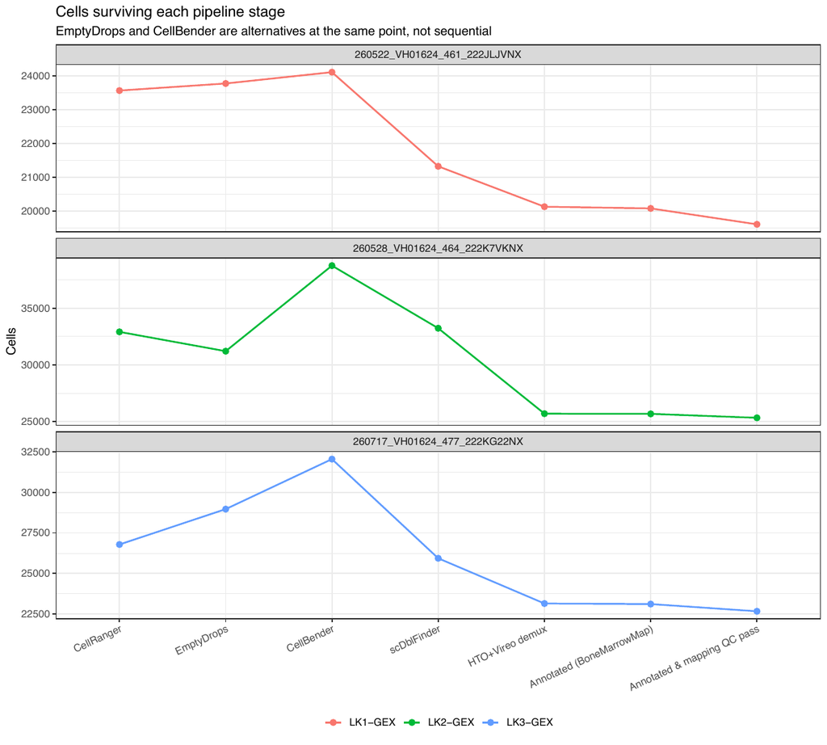

Cells lost at each transition

| run | sample | step | n_cells_lost |
| --- | --- | --- | --- |
| `260522_VH01624_461_222JLJVNX` | LK1-GEX | CellRanger -> EmptyDrops | 424 |
| `260522_VH01624_461_222JLJVNX` | LK1-GEX | CellRanger -> CellBender | 304 |
| `260522_VH01624_461_222JLJVNX` | LK1-GEX | EmptyDrops -> scDblFinder singlets | 3375 |
| `260522_VH01624_461_222JLJVNX` | LK1-GEX | CellBender -> scDblFinder singlets | 2794 |
| `260522_VH01624_461_222JLJVNX` | LK1-GEX | scDblFinder singlets -> demux singlets | 1199 |
| `260522_VH01624_461_222JLJVNX` | LK1-GEX | Demux singlets -> annotated (mapping QC fail) | 473 |
| `260528_VH01624_464_222K7VKNX` | LK2-GEX | CellRanger -> EmptyDrops | 3325 |
| `260528_VH01624_464_222K7VKNX` | LK2-GEX | CellRanger -> CellBender | 202 |
| `260528_VH01624_464_222K7VKNX` | LK2-GEX | EmptyDrops -> scDblFinder singlets | 5979 |
| `260528_VH01624_464_222K7VKNX` | LK2-GEX | CellBender -> scDblFinder singlets | 5519 |
| `260528_VH01624_464_222K7VKNX` | LK2-GEX | scDblFinder singlets -> demux singlets | 7538 |
| `260528_VH01624_464_222K7VKNX` | LK2-GEX | Demux singlets -> annotated (mapping QC fail) | 348 |
| `260717_VH01624_477_222KG22NX` | LK3-GEX | CellRanger -> EmptyDrops | 85 |
| `260717_VH01624_477_222KG22NX` | LK3-GEX | CellRanger -> CellBender | 87 |
| `260717_VH01624_477_222KG22NX` | LK3-GEX | EmptyDrops -> scDblFinder singlets | 5904 |
| `260717_VH01624_477_222KG22NX` | LK3-GEX | CellBender -> scDblFinder singlets | 6112 |
| `260717_VH01624_477_222KG22NX` | LK3-GEX | scDblFinder singlets -> demux singlets | 2789 |
| `260717_VH01624_477_222KG22NX` | LK3-GEX | Demux singlets -> annotated (mapping QC fail) | 445 |

# 6. The two cell callers

Barcode overlap between the two callers

| run | sample | n_emptydrops | n_cellbender | n_common | n_emptydrops_only | n_cellbender_only | pct_jaccard |
| --- | --- | --- | --- | --- | --- | --- | --- |
| `260522_VH01624_461_222JLJVNX` | LK1-GEX | 23779 | 24115 | 22938 | 841 | 1177 | 91.9 |
| `260528_VH01624_464_222K7VKNX` | LK2-GEX | 31201 | 38747 | 29852 | 1349 | 8895 | 74.5 |
| `260717_VH01624_477_222KG22NX` | LK3-GEX | 28968 | 32050 | 27404 | 1564 | 4646 | 81.5 |

**`02_cell_caller_overlap.pdf`**

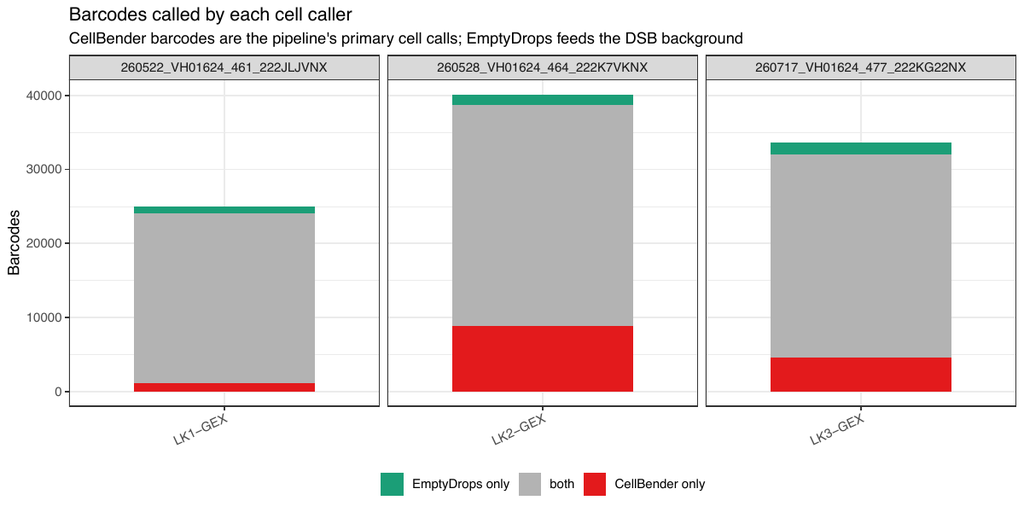

Both callers run on every sample, and both outputs are used - CellBender’s barcodes are the cell calls, emptyDrops’ barcodes define the background droplets DSB needs. So the overlap is not academic: the two sets disagree by 25% in LK2, and each disagreement region feeds a different part of the downstream analysis.

# 7. Runtime

Nextflow writes no trace file here - only `report` and `dag` are enabled in the config - but its HTML execution report embeds the full per-task trace as JSON, which is where these numbers come from. They are Nextflow’s own accounting, not a re-measurement.

Per run. wall_total_if_serial is the sum of task runtimes, not elapsed time

| run | n_tasks | cached | failed | wall_total_if_serial | cpu_hours |
| --- | --- | --- | --- | --- | --- |
| `260522_VH01624_461_222JLJVNX` | 28 | 0 | 0 | 24:52:50 | 268.35 |
| `260528_VH01624_464_222K7VKNX` | 28 | 27 | 0 | 35:02:14 | 351.04 |
| `260717_VH01624_477_222KG22NX` | 25 | 25 | 0 | 28:07:50 | 284.82 |

Elapsed wall clock against work done. concurrency = work / elapsed

| run | elapsed_h | work_h | concurrency |
| --- | --- | --- | --- |
| `260522_VH01624_461_222JLJVNX` | 11.58 | 24.88 | 2.15 |
| `260528_VH01624_464_222K7VKNX` | 23.59 | 35.04 | 1.48 |
| `260717_VH01624_477_222KG22NX` | 16.55 | 28.13 | 1.70 |

`CACHED` is a success, not a failure - it means Nextflow resumed that task from a previous run’s work directory instead of re-executing it. LK1 was executed in full; LK2 and LK3 are almost entirely resumed. **No task failed in any run.**

**`06_pipeline_timeline.pdf`**

One bar per task, positioned from the first submit of its run. Overlapping bars ran concurrently, so panel width is elapsed time while the total bar length is work done. The long serial spine at the start - Cell Ranger, then CellBender and cellSNP - is what sets the floor on how fast a run can finish.

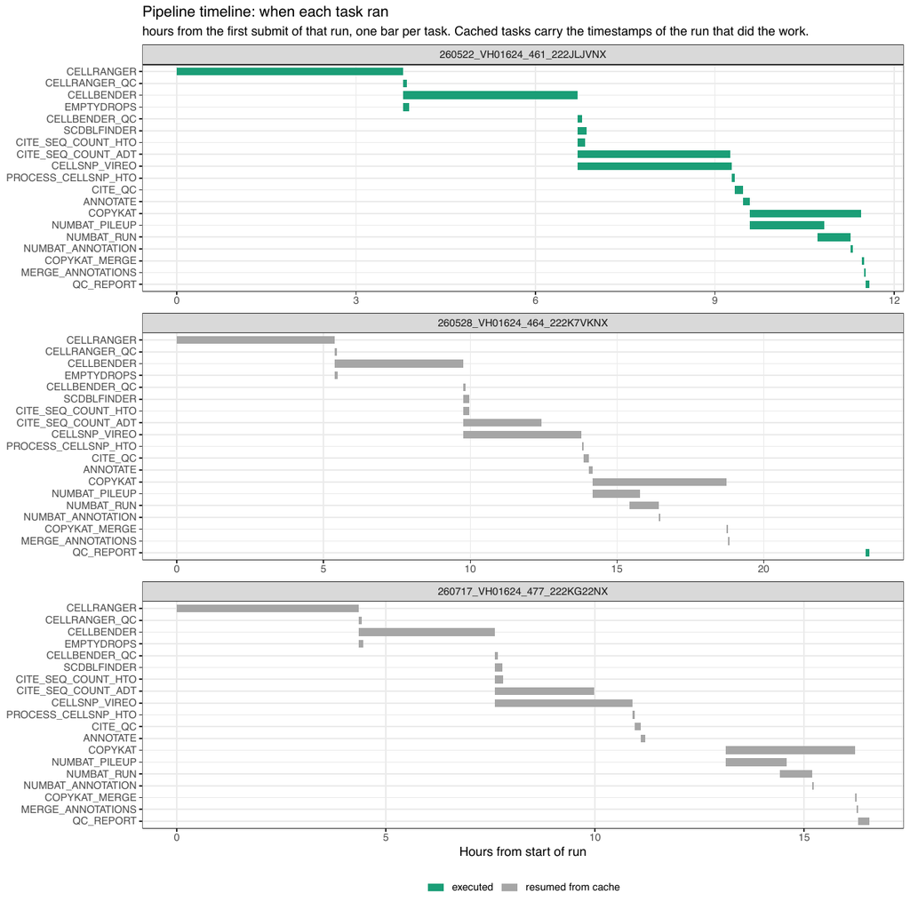

Per process per run, longest first

| run | process | n_tasks | cached | wall_total | wall_longest | cpu_hours | peak_rss_gb |
| --- | --- | --- | --- | --- | --- | --- | --- |
| `260522_VH01624_461_222JLJVNX` | `COPYKAT` | 4 | 0 | 06:04:25 | 01:51:35 | 12.15 | 42.57 |
| `260522_VH01624_461_222JLJVNX` | `NUMBAT_PILEUP` | 4 | 0 | 04:49:59 | 01:14:55 | 77.33 | 1.84 |
| `260522_VH01624_461_222JLJVNX` | `CELLRANGER` | 1 | 0 | 03:46:58 | 03:46:58 | 60.52 | 62.36 |
| `260522_VH01624_461_222JLJVNX` | `CELLBENDER` | 1 | 0 | 02:55:02 | 02:55:02 | 11.67 | 40.89 |
| `260522_VH01624_461_222JLJVNX` | `CELLSNP_VIREO` | 1 | 0 | 02:34:45 | 02:34:45 | 41.27 | 1.49 |
| `260522_VH01624_461_222JLJVNX` | `CITE_SEQ_COUNT_ADT` | 1 | 0 | 02:32:44 | 02:32:44 | 40.73 | 241.62 |
| `260522_VH01624_461_222JLJVNX` | `NUMBAT_RUN` | 4 | 0 | 01:13:35 | 00:25:47 | 19.62 | 53.06 |
| `260522_VH01624_461_222JLJVNX` | `SCDBLFINDER` | 1 | 0 | 00:08:47 | 00:08:47 | 0.59 | 15.64 |
| `260522_VH01624_461_222JLJVNX` | `CITE_QC` | 1 | 0 | 00:07:28 | 00:07:28 | 0.50 | 7.95 |
| `260522_VH01624_461_222JLJVNX` | `CITE_SEQ_COUNT_HTO` | 1 | 0 | 00:07:19 | 00:07:19 | 1.95 | 12.28 |
| `260522_VH01624_461_222JLJVNX` | `ANNOTATE` | 1 | 0 | 00:06:39 | 00:06:39 | 0.44 | 10.33 |
| `260522_VH01624_461_222JLJVNX` | `EMPTYDROPS` | 1 | 0 | 00:05:52 | 00:05:52 | 0.39 | 10.11 |
| `260522_VH01624_461_222JLJVNX` | `CELLRANGER_QC` | 1 | 0 | 00:03:55 | 00:03:55 | 0.26 | 9.05 |
| `260522_VH01624_461_222JLJVNX` | `CELLBENDER_QC` | 1 | 0 | 00:03:51 | 00:03:51 | 0.26 | 8.89 |
| `260522_VH01624_461_222JLJVNX` | `PROCESS_CELLSNP_HTO` | 1 | 0 | 00:02:55 | 00:02:55 | 0.19 | 7.08 |
| `260522_VH01624_461_222JLJVNX` | `QC_REPORT` | 1 | 0 | 00:02:42 | 00:02:42 | 0.18 | 5.16 |
| `260522_VH01624_461_222JLJVNX` | `NUMBAT_ANNOTATION` | 1 | 0 | 00:02:02 | 00:02:02 | 0.14 | 2.48 |
| `260522_VH01624_461_222JLJVNX` | `MERGE_ANNOTATIONS` | 1 | 0 | 00:02:01 | 00:02:01 | 0.13 | 5.09 |
| `260522_VH01624_461_222JLJVNX` | `COPYKAT_MERGE` | 1 | 0 | 00:01:52 | 00:01:52 | 0.03 | 2.32 |
| `260528_VH01624_464_222K7VKNX` | `COPYKAT` | 4 | 4 | 10:18:15 | 04:34:18 | 20.61 | 61.00 |
| `260528_VH01624_464_222K7VKNX` | `NUMBAT_PILEUP` | 4 | 4 | 05:39:40 | 01:37:55 | 90.58 | 2.89 |
| `260528_VH01624_464_222K7VKNX` | `CELLRANGER` | 1 | 1 | 05:22:15 | 05:22:15 | 85.94 | 61.12 |
| `260528_VH01624_464_222K7VKNX` | `CELLBENDER` | 1 | 1 | 04:23:46 | 04:23:46 | 17.58 | 53.60 |
| `260528_VH01624_464_222K7VKNX` | `CELLSNP_VIREO` | 1 | 1 | 04:01:37 | 04:01:37 | 64.43 | 1.98 |
| `260528_VH01624_464_222K7VKNX` | `CITE_SEQ_COUNT_ADT` | 1 | 1 | 02:39:53 | 02:39:53 | 42.64 | 311.17 |
| `260528_VH01624_464_222K7VKNX` | `NUMBAT_RUN` | 4 | 4 | 01:23:07 | 00:38:23 | 22.16 | 57.10 |
| `260528_VH01624_464_222K7VKNX` | `SCDBLFINDER` | 1 | 1 | 00:12:15 | 00:12:15 | 0.82 | 16.43 |
| `260528_VH01624_464_222K7VKNX` | `CITE_SEQ_COUNT_HTO` | 1 | 1 | 00:11:29 | 00:11:29 | 3.06 | 18.39 |
| `260528_VH01624_464_222K7VKNX` | `CITE_QC` | 1 | 1 | 00:09:21 | 00:09:21 | 0.62 | 10.09 |
| `260528_VH01624_464_222K7VKNX` | `ANNOTATE` | 1 | 1 | 00:07:23 | 00:07:23 | 0.49 | 13.37 |
| `260528_VH01624_464_222K7VKNX` | `EMPTYDROPS` | 1 | 1 | 00:06:53 | 00:06:53 | 0.46 | 12.55 |
| `260528_VH01624_464_222K7VKNX` | `QC_REPORT` | 1 | 0 | 00:06:17 | 00:06:17 | 0.42 | 6.74 |
| `260528_VH01624_464_222K7VKNX` | `CELLRANGER_QC` | 1 | 1 | 00:04:57 | 00:04:57 | 0.33 | 9.80 |
| `260528_VH01624_464_222K7VKNX` | `CELLBENDER_QC` | 1 | 1 | 00:04:35 | 00:04:35 | 0.31 | 10.30 |
| `260528_VH01624_464_222K7VKNX` | `PROCESS_CELLSNP_HTO` | 1 | 1 | 00:03:36 | 00:03:36 | 0.24 | 9.50 |
| `260528_VH01624_464_222K7VKNX` | `MERGE_ANNOTATIONS` | 1 | 1 | 00:02:23 | 00:02:23 | 0.16 | 5.90 |
| `260528_VH01624_464_222K7VKNX` | `NUMBAT_ANNOTATION` | 1 | 1 | 00:02:22 | 00:02:22 | 0.16 | 2.84 |
| `260528_VH01624_464_222K7VKNX` | `COPYKAT_MERGE` | 1 | 1 | 00:02:10 | 00:02:10 | 0.04 | 2.67 |
| `260717_VH01624_477_222KG22NX` | `COPYKAT` | 3 | 3 | 08:06:01 | 03:05:50 | 16.20 | 41.95 |
| `260717_VH01624_477_222KG22NX` | `CELLRANGER` | 1 | 1 | 04:20:28 | 04:20:28 | 69.46 | 60.48 |
| `260717_VH01624_477_222KG22NX` | `NUMBAT_PILEUP` | 3 | 3 | 04:12:49 | 01:28:06 | 67.42 | 1.46 |
| `260717_VH01624_477_222KG22NX` | `CELLSNP_VIREO` | 1 | 1 | 03:17:16 | 03:17:16 | 52.61 | 1.26 |
| `260717_VH01624_477_222KG22NX` | `CELLBENDER` | 1 | 1 | 03:15:38 | 03:15:38 | 13.04 | 38.80 |
| `260717_VH01624_477_222KG22NX` | `CITE_SEQ_COUNT_ADT` | 1 | 1 | 02:22:34 | 02:22:34 | 38.02 | 204.66 |
| `260717_VH01624_477_222KG22NX` | `NUMBAT_RUN` | 3 | 3 | 01:18:31 | 00:35:38 | 20.94 | 57.80 |
| `260717_VH01624_477_222KG22NX` | `QC_REPORT` | 1 | 1 | 00:15:32 | 00:15:32 | 1.04 | 5.61 |
| `260717_VH01624_477_222KG22NX` | `CITE_SEQ_COUNT_HTO` | 1 | 1 | 00:11:15 | 00:11:15 | 3.00 | 14.81 |
| `260717_VH01624_477_222KG22NX` | `SCDBLFINDER` | 1 | 1 | 00:10:45 | 00:10:45 | 0.72 | 13.48 |
| `260717_VH01624_477_222KG22NX` | `CITE_QC` | 1 | 1 | 00:07:49 | 00:07:49 | 0.52 | 7.15 |
| `260717_VH01624_477_222KG22NX` | `ANNOTATE` | 1 | 1 | 00:06:41 | 00:06:41 | 0.45 | 10.93 |
| `260717_VH01624_477_222KG22NX` | `EMPTYDROPS` | 1 | 1 | 00:05:47 | 00:05:47 | 0.39 | 9.84 |
| `260717_VH01624_477_222KG22NX` | `CELLRANGER_QC` | 1 | 1 | 00:04:07 | 00:04:07 | 0.27 | 7.55 |
| `260717_VH01624_477_222KG22NX` | `CELLBENDER_QC` | 1 | 1 | 00:04:07 | 00:04:07 | 0.27 | 8.41 |
| `260717_VH01624_477_222KG22NX` | `PROCESS_CELLSNP_HTO` | 1 | 1 | 00:02:51 | 00:02:51 | 0.19 | 6.17 |
| `260717_VH01624_477_222KG22NX` | `NUMBAT_ANNOTATION` | 1 | 1 | 00:02:00 | 00:02:00 | 0.13 | 2.36 |
| `260717_VH01624_477_222KG22NX` | `MERGE_ANNOTATIONS` | 1 | 1 | 00:01:55 | 00:01:55 | 0.13 | 4.77 |
| `260717_VH01624_477_222KG22NX` | `COPYKAT_MERGE` | 1 | 1 | 00:01:43 | 00:01:43 | 0.03 | 2.20 |

Wall-clock time per process, runs side by side

| process | 260522_VH01624_461_222JLJVNX | 260528_VH01624_464_222K7VKNX | 260717_VH01624_477_222KG22NX |
| --- | --- | --- | --- |
| `COPYKAT` | 06:04:25 | 10:18:15 | 08:06:01 |
| `NUMBAT_PILEUP` | 04:49:59 | 05:39:40 | 04:12:49 |
| `CELLRANGER` | 03:46:58 | 05:22:15 | 04:20:28 |
| `CELLBENDER` | 02:55:02 | 04:23:46 | 03:15:38 |
| `CELLSNP_VIREO` | 02:34:45 | 04:01:37 | 03:17:16 |
| `CITE_SEQ_COUNT_ADT` | 02:32:44 | 02:39:53 | 02:22:34 |
| `NUMBAT_RUN` | 01:13:35 | 01:23:07 | 01:18:31 |
| `SCDBLFINDER` | 00:08:47 | 00:12:15 | 00:10:45 |
| `CITE_QC` | 00:07:28 | 00:09:21 | 00:07:49 |
| `CITE_SEQ_COUNT_HTO` | 00:07:19 | 00:11:29 | 00:11:15 |
| `ANNOTATE` | 00:06:39 | 00:07:23 | 00:06:41 |
| `EMPTYDROPS` | 00:05:52 | 00:06:53 | 00:05:47 |
| `CELLRANGER_QC` | 00:03:55 | 00:04:57 | 00:04:07 |
| `CELLBENDER_QC` | 00:03:51 | 00:04:35 | 00:04:07 |
| `PROCESS_CELLSNP_HTO` | 00:02:55 | 00:03:36 | 00:02:51 |
| `QC_REPORT` | 00:02:42 | 00:06:17 | 00:15:32 |
| `NUMBAT_ANNOTATION` | 00:02:02 | 00:02:22 | 00:02:00 |
| `MERGE_ANNOTATIONS` | 00:02:01 | 00:02:23 | 00:01:55 |
| `COPYKAT_MERGE` | 00:01:52 | 00:02:10 | 00:01:43 |

**`03_runtime_by_process.pdf`**

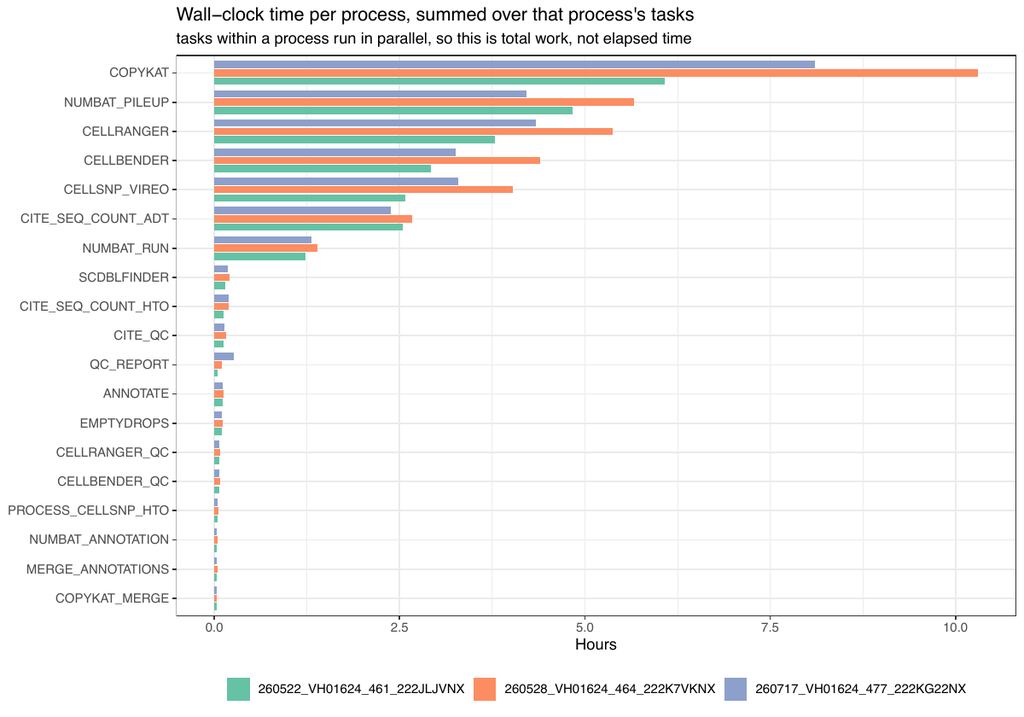

**`04_cpu_hours_by_process.pdf`**

Allocated CPU hours - realtime times allocated cpus, so what the process costs the cluster rather than what it uses.

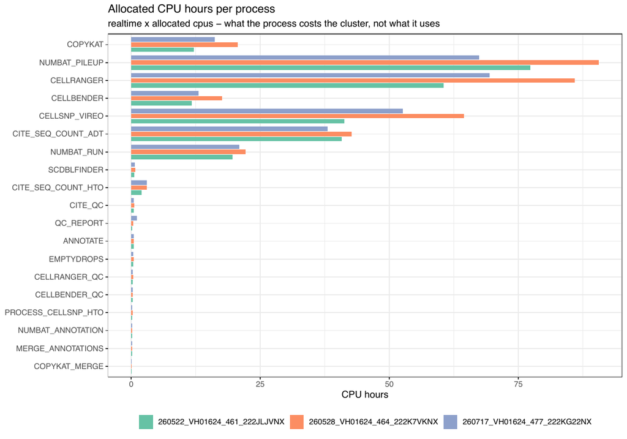

**`05_peak_memory_by_process.pdf`**

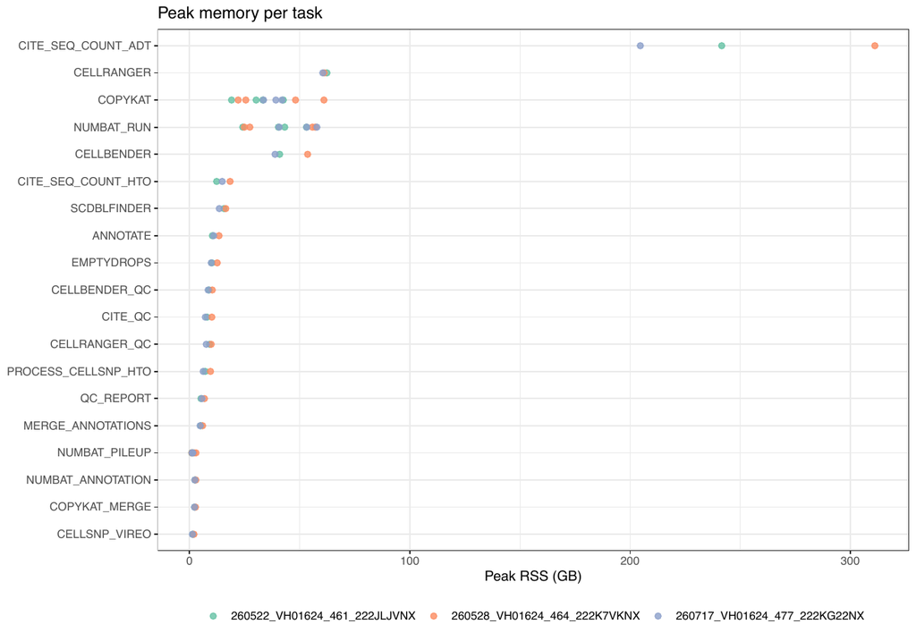

Three things stand out. **CopyKAT is the most expensive step** - 10h19m of wall clock across its four per-donor tasks in LK2, more than Cell Ranger. **The pipeline is only 1.5-2.2x concurrent**, because the early stages are a serial chain on one sample before the per-donor fan-out begins. And **CITE_SEQ_COUNT_ADT peaks at 311 GB RSS**, which is worth checking against what its process directive actually requests.

# 8. Which run is which

Run identity

| run | short | note |
| --- | --- | --- |
| `260423_VH01624_453_222HWMYNX` | LK1 pilot | NOT in the pipeline samplesheet. Superseded by the re-sequencing; analysed only by the standalone scripts in reports 01, 07 and 08. |
| `260522_VH01624_461_222JLJVNX` | LK1 re-sequenced | What the pipeline runs for LK1. |
| `260528_VH01624_464_222K7VKNX` | LK2 | Run by both the pipeline and the standalone scripts. |
| `260717_VH01624_477_222KG22NX` | LK3 | Pipeline only. Carries the unhashed donor WEI21_26-17_NK. |

# 9. Observations

Recorded rather than fixed - the pipeline is a separate repository and nothing in this report modifies it.

Things worth deciding about

| issue | where | detail |
| --- | --- | --- |
| params.cell_caller is declared and never used | `nextflow.config` | It is set to “emptydrops”, but the workflow assigns cell_barcodes = CELLBENDER.out.cellbender_barcodes unconditionally. The parameter says the opposite of what the DAG does, and changing it would have… |
| MAD_threshold differs between the two annotation code paths | `bin/annotate.R vs bin/lib_early_qc_annotation.R` | annotate.R, the live ANNOTATE process, uses 4. lib_early_qc_annotation.R uses the BoneMarrowMap default of 2.5. The standalone benchmark scripts also used 2.5, so results_nf and results/seurat_annotat… |
| leftover debug logging in the workflow | `main.nf` | A log.info marked “TEMP DEBUG - remove once NUMBAT_PILEUP null-path bug is confirmed fixed” still fires for every donor of every run. |
| donor names differ between the pipeline and the standalone analyses | `conf/samples.csv` | samples.csv has HBDN206-MN-pCT, HBDN392-MDS, HBDN501-KMT2A; the standalone scripts and results use HBDN206-MNpCT, HBDN392-AML-MDS, HBDN501-AML-KMT2A. Same donors, different strings, so joins between t… |
| the Numbat container is pinned to `latest` | `nextflow.config` | numbat_sif points at numbat-rbase_latest.sif. The version that produced the published results is not recoverable from the image name. |
| conda environments are absolute paths in one home directory | `nextflow.config` | r_env, cite_seq_count_env, cellsnp_env and cellranger_bin are all under /home/nbartonicek, so the pipeline only runs as this user. |
| DOROTHEA_VIPER is a dead module | `modules/dorothea_viper.nf, bin/dorothea_viper.R` | The module and its R script exist, but the process is neither included nor called anywhere in main.nf, so it never runs. It is the only module of the 18 that is not wired into the workflow. |

# 10. What was run

| Step | Script | What |
| --- | --- | --- |
| 01 | `01.pipeline_inventory.R` | Parses modules/, main.nf and nextflow.config into process, parameter and resource tables, and checks which processes are actually wired into the workflow. |
| 02a | `02a.pipeline_runtimes.R` | Parses the per-task trace out of Nextflow’s HTML execution reports and summarises runtime, CPU hours, peak memory and the schedule. |
| 02 | `02.pipeline_outputs_and_params.R` | Inventories the published output tree per run, reads the cell-count funnel and cell-caller overlap, and compares every parameter against the benchmark that determined it. |
| 03 | `03.nextflow_workflow_report.Rmd` | This report. |

Unlike reports 01-08 there are no analysis scripts of mine to collate here - the pipeline itself is the artefact. These two steps read it and write down what they find; neither writes anything into `nextflow/`.

# 11. Data locations

| What | Where |
| --- | --- |
| Pipeline | `nextflow/ - separate git repository, nbartonicek/surface_proteome` |
| Entry point | `nextflow/main.nf` |
| Process definitions | `nextflow/modules/*.nf` |
| Analysis code | `nextflow/bin/*.R and qc_report.Rmd` |
| Configuration | `nextflow/nextflow.config` |
| Samplesheet | `nextflow/conf/samples.csv` |
| Launcher | `nextflow/run_nextflow.sh` |
| Published output | `results_nf/<run>/` |
| Nextflow’s own DAG and execution reports | `results_nf/pipeline_dag.html, results_nf/execution_report_<run>.html` |
| Tables and figures for this report | `results/benchmarking/nextflow_workflow` |

# 12. Caveats